## [DRAFT] Data Carpentry’s Paired Pre and Post-Workshop Survey Report

March 2018

# Pre-Workshop Survey Demographics

## Workshop Location

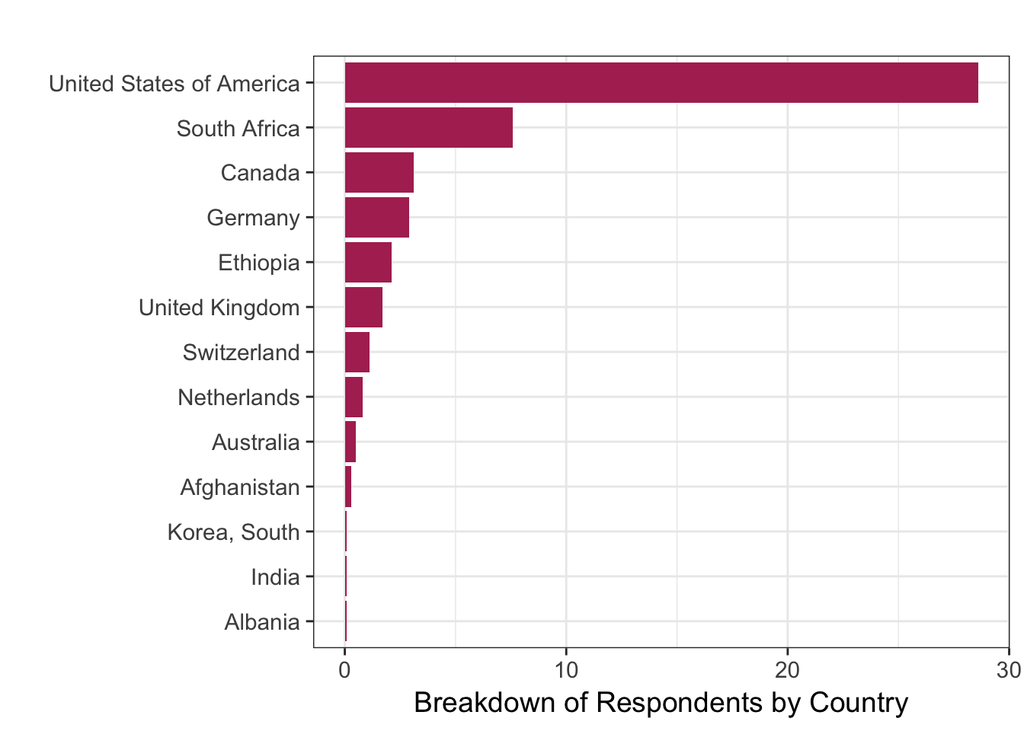

## Respondents Discipline

| Respondents Discipline | n | % |
| --- | --- | --- |
| Life Sciences | 189 | 1.9 |
| Agricultural or Environmental Sciences | 165 | 1.7 |
| Bioinformatics/Genomics | 106 | 1.1 |
| Biomedical/Health Sciences | 103 | 1.1 |
| Social Sciences | 70 | 0.7 |
| Engineering | 64 | 0.7 |
| Mathematics or Statistics | 56 | 0.6 |
| Computer Science | 47 | 0.5 |
| Earth Sciences | 43 | 0.4 |
| Business/Economics | 36 | 0.4 |
| Humanities | 33 | 0.3 |
| Library Sciences | 22 | 0.2 |
| Physical Sciences | 18 | 0.2 |

## Respondents Status

Status

| Status | n | % |
| --- | --- | --- |
| Graduate Student | 374 | 5.5 |
| Research Staff | 72 | 1.1 |
| Postdoctoral Researcher | 59 | 0.9 |
| Faculty | 51 | 0.8 |
| Government Employee | 29 | 0.4 |
| Undergraduate Student | 21 | 0.3 |
| Retired/Not Employed | 16 | 0.2 |
| Industry Employee | 15 | 0.2 |
| Management/Administrator | 8 | 0.1 |

## Pre/Post Comparison

Learners were asked to rate their level of agreement with the following statements related to Data Carpentry’s workshop goals and learning objectives. The figure below provides a visual representation of their responses, comparing them before the workshop and after the workshop. Axis labels and the corresponding question are as follows:

- **AnalysesEasier**: Using a programming language (like R or Python) can make my analyses easier to reproduce.
- **OvercomeProblem**: While working on a programming project, if I get stuck, I can find ways of overcoming the problem.
- **ProgrammingSoftware**: I am confident in my ability to make use of programming software to work with data.
- **RawData**: Having access to the original, raw data is important to be able to repeat an analysis.
- **SearchOnline**: I know how to search for answers to my technical questions online.
- **WriteScript**: I can write a small program/script/macro to solve a problem in my own work.

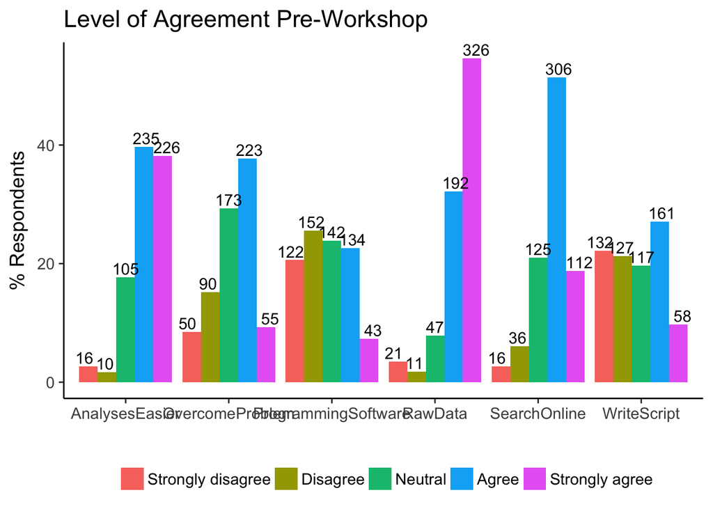

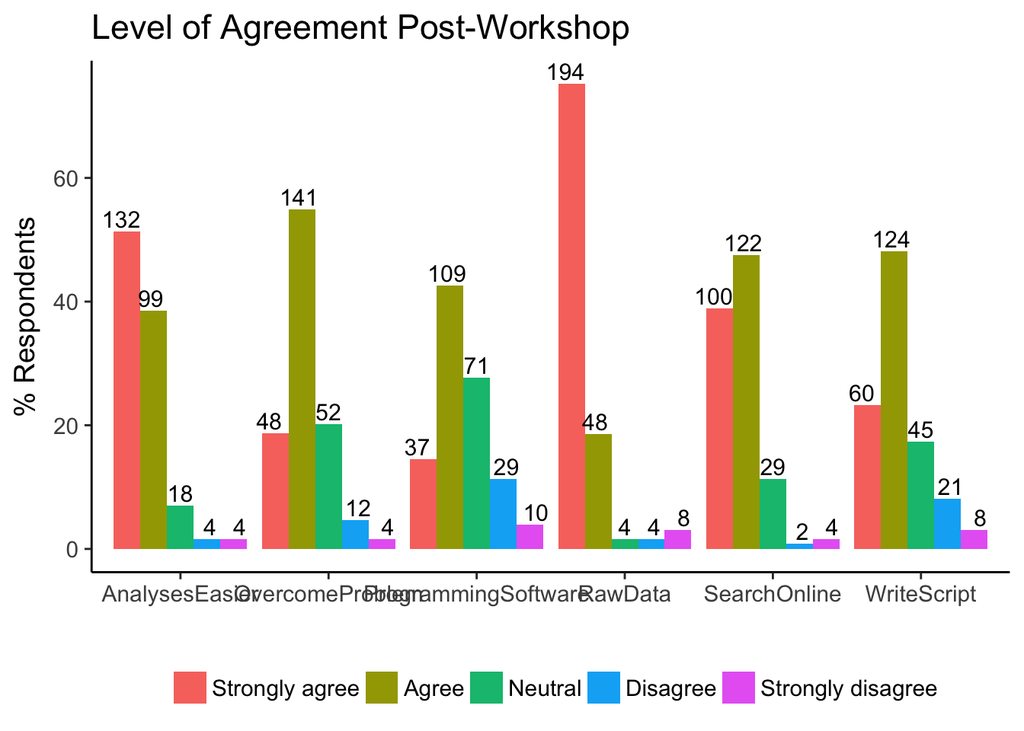

## Paired Analyses Table

| skill | mean_pre_feeling | sd_pre_feeling | mean_post_feeling | sd_post_feeling | n_pre | n_post | p.value |
| --- | --- | --- | --- | --- | --- | --- | --- |
| AnalysesEasier | 4.104167 | 0.9139077 | 4.377778 | 0.7713786 | 144 | 135 | 0.0031887 |
| OvercomeProblem | 3.181818 | 1.0183967 | 3.807407 | 0.8149379 | 143 | 135 | 0.0000000 |
| ProgrammingSoftware | 2.542254 | 1.2182026 | 3.533333 | 0.9910043 | 142 | 135 | 0.0000000 |
| RawData | 4.416667 | 0.9274373 | 4.622222 | 0.8540218 | 144 | 135 | 0.0419499 |
| SearchOnline | 3.805556 | 0.8712805 | 4.281481 | 0.7595349 | 144 | 135 | 0.0000002 |
| WriteScript | 2.601399 | 1.3486554 | 3.792593 | 0.9470795 | 143 | 135 | 0.0000000 |

# Recommending Data Carpentry Workshops

Learners were asked how likely they are to recommend this workshop to a friend or colleague using the [Net Promoter Score](https://en.wikipedia.org/wiki/Net_Promoter). The scoring for this question based on a 0 to 100 scale. Respondents scoring from 0 to 64 are labeled *Detractors*, and are believed to be less likely to recommend a workshop. Those who respond with a score of 85 to 100 are called *Promoters*, and are considered likely to recommend a workshop. Respondents between 65 and 84 are labeled *Passives*, and their behavior falls in the middle of Promoters and Detractors.

| Promoter Score | n | % |
| --- | --- | --- |
| Detractor | 14 | 5.511811 |
| Passive | 49 | 19.291339 |
| Promoter | 191 | 75.196850 |